# Course 5: Reproducible research, week 5: PA1_template

Hicham el Bouazzaoui

3 april 2017

### 1. Code for reading in the dataset and/or processing the data

First the working directory is set, then the data is downloaded and loaded and finally the necessary libraries are loaded. After the data is loaded, the data is saved in a variable and the necessary transformations are carried out.

```r
setwd("C:/Users/helbouazzaoui/Desktop/Coursera course/Data science course/Course 5 Reproducible Research/Week 2")

fileurl <- "https://d396qusza40orc.cloudfront.net/repdata%2Fdata%2Factivity.zip"

if(!file.exists("./data")){dir.create("./data")}
download.file(fileurl, destfile = "./data/exdata_data_NEI_data.zip", method = "curl")

unzip("./data/exdata_data_NEI_data.zip", overwrite = T, unzip = "internal")

act_data <- read.csv("activity.csv", sep=",",na.strings="NA")

act_data$date <- as.Date(act_data$date, format = '%Y-%m-%d')

library(data.table)
library(ggplot2)
```

### 2. Histogram of the total number of steps taken each day

A histogram of the total number of steps taken each day is created using the loaded data.

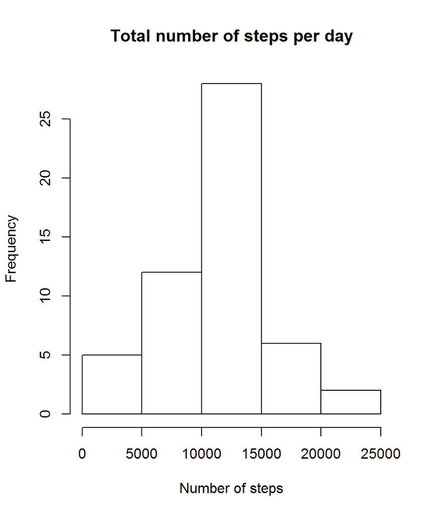

```r
tmp <- data.table(act_data)
total_steps_perday <- tmp[, list(steps = sum(steps)), by = c("date")]

hist(total_steps_perday$steps,
     main = "Total number of steps per day",
     xlab = "Number of steps",
     ylab = "Frequency"
     )
```

### 3. Mean and median number of steps taken each day

The mean and median are calculated using the total steps taken per day. The NA values are removed when calculating the mean and median.

```r
median(total_steps_perday$steps, na.rm = TRUE)
```

```
## [1] 10765
```

```r
mean(total_steps_perday$steps, na.rm = TRUE)
```

```
## [1] 10766.19
```

### 4. Time series plot of the average number of steps taken

First the average number of steps taken for each interval is calculated. This is done by using the data.table package and calculated the the mean steps for each interval across al days.

```r
tmp_int <- data.table(act_data)
tmp_int$steps[is.na(tmp_int$steps)] <- 0
average_steps_perinterval <- tmp_int[, list(steps = mean(steps)), by = c("interval")]
```

Using the average number of steps per internval, a time series plot is created

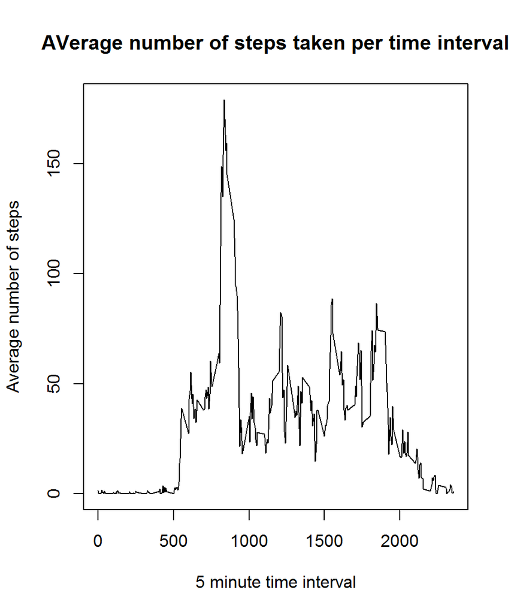

```r
plot(average_steps_perinterval$interval, average_steps_perinterval$steps, type = "l",
     main = "AVerage number of steps taken per time interval",
     xlab = "5 minute time interval",
     ylab = "Average number of steps")
```

### 5. The 5-minute interval that, on average, contains the maximum number of steps

First find the index of the maximum number of steps.

```r
max_steps <- which(average_steps_perinterval$steps == max(average_steps_perinterval$steps))
```

Then find the interval that belongs to this index.

```r
average_steps_perinterval$interval[max_steps]
```

```
## [1] 835
```

Count the number of missing values

```r
sum(is.na(act_data$steps))
```

```
## [1] 2304
```

### 6. Code to describe and show a strategy for imputing missing data

First create a new temporary data set, where the whole data set is reloaded

```r
tmp_data <- act_data
```

Then the mean for each interval is recalculated and used to fill up the missing values

```r
mean_steps_perinterval <- aggregate(steps~interval, tmp_data,mean)
```

```r
tmp_actdata <- merge(act_data, mean_steps_perinterval, by = 'interval', suffixes = c("","_mean_per_interval"))
index_na <- which(is.na(tmp_actdata$steps))
tmp_actdata$steps[index_na] <- tmp_actdata$steps_mean_per_interval[index_na]
```

A new dataset is created whitout missing values

```r
total_data <- tmp_actdata[,1:3]
```

### 7. Histogram of the total number of steps taken each day after missing values are imputed

A subset of the data is created using the data.table package

```r
tmp_tot <- data.table(total_data)
new_steps_perinterval <- tmp_tot[, list(steps = sum(steps)), by = c("date")]
```

A histogram of the total number of steps per day is created

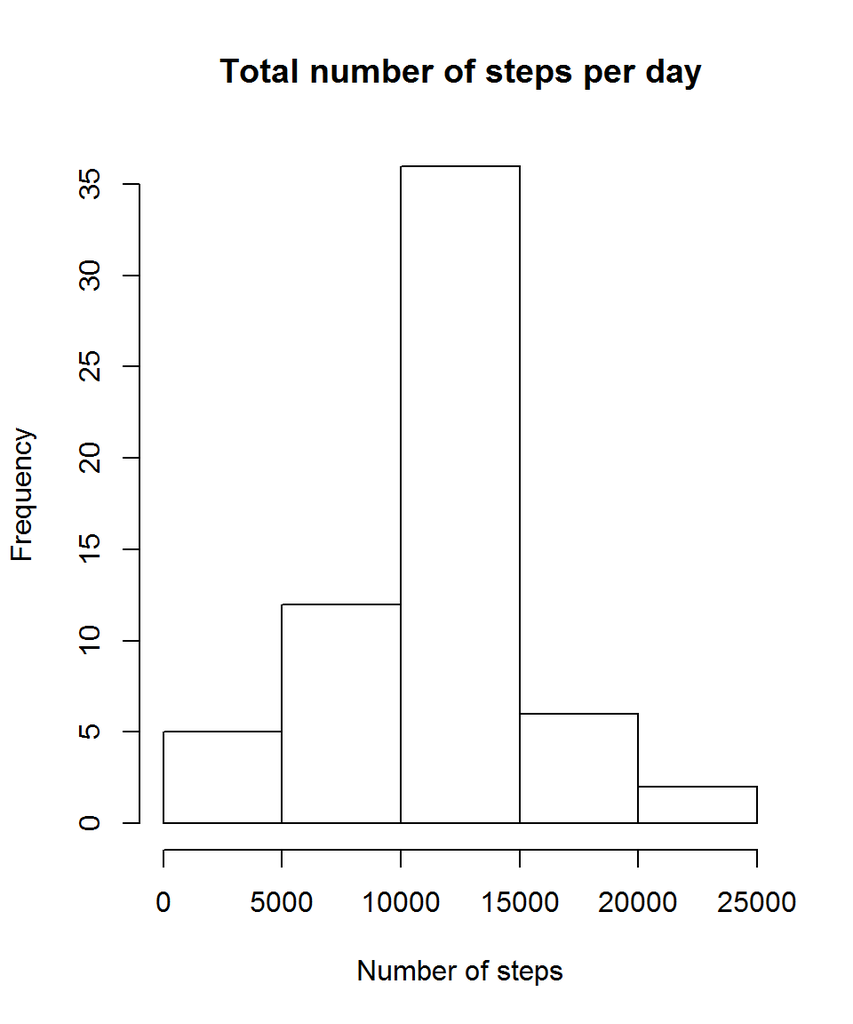

```r
hist(new_steps_perinterval$steps,
     main = "Total number of steps per day",
     xlab = "Number of steps",
     ylab = "Frequency"
)
```

The new median and mean are then calculated

```r
median(new_steps_perinterval$steps)
```

```
## [1] 10766.19
```

```r
mean(new_steps_perinterval$steps)
```

```
## [1] 10766.19
```

### 8. Panel plot comparing the average number of steps taken per 5-minute interval across weekdays and weekends

```r
Sys.setlocale("LC_TIME", "English")
```

```
## [1] "English_United States.1252"
```

A new factor variable with two levels. This variable is joined into the existing data variable

```r
total_data$day[weekdays(total_data$date) %in% c("Monday","Tuesday","Wednesday","Thursday","Friday")]<-"weekday"
total_data$day[weekdays(total_data$date) %in% c("Saturday", "Sunday")]<-"weekend"
```

The data set of the 5 minute interval data averaged across the weekdays and weekends is created for the plot using the data.table package

```r
tmp_total_data <- data.table(total_data)
new_average_steps_perinterval <- tmp_total_data[, list(steps = mean(steps)), by = c("day","interval")]
```

A time series plot is created using the ggplot function, where the plots for weekdays and weekend are shown on top of each other

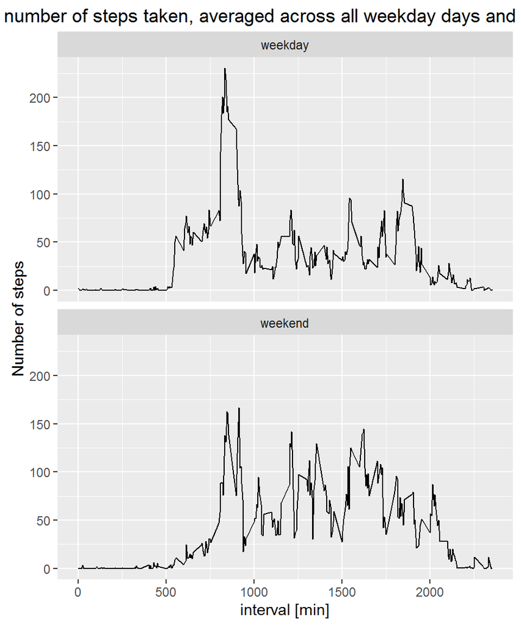

```r
g <- ggplot(new_average_steps_perinterval, aes(interval, steps))
g + geom_line(stat = "identity") +
  facet_wrap(~day, nrow = 2) +
  labs(x = "interval [min]") +
  labs(y = "Number of steps") +
  labs(title = "Average number of steps taken, averaged across all weekday days and weekend days" )
```